# Soluciones P4: ANOVA y regresión en R

**Soluciones P4:**  
ANOVA y regresión en `R`

Marta Coronado Zamora Noviembre 2026

En estas soluciones leemos los ficheros desde la carpeta de la práctica. Si usas el enlace URL (`https://raw.githubusercontent.com/marta-coronado/biostatistics-uab/refs/heads/main/P/4/...`), el resultado es exactamente el mismo.

# Parte 1. ANOVA de una vía: biodiversidad de insectos

### 1. Leer los datos

```r
insectos <- read.table("urban_data_filter.tsv", header = TRUE, sep = "\t")
head(insectos)
```

```
##   Sample Urban.Type Lawn Richness Temp.Mean Photoperiod  Rh.Mean
## 1  15419          3  Yes       30  16.12931    10.05777 41.65878
## 2  15426          8  Yes        3  14.00196    10.06396 64.32544
## 3  15438          9   No       22  13.79680    10.06042 63.47510
## 4  15448          9  Yes        1  14.69578    10.06268 65.77493
## 5  15455          8   No       22  14.17297    10.06138 56.98914
## 6  15456          8   No       15  15.73808    10.19417 57.51313
```

```r
str(insectos)
```

```
## 'data.frame':    240 obs. of  7 variables:
##  $ Sample     : int  15419 15426 15438 15448 15455 15456 15462 15465 15467 15476 ...
##  $ Urban.Type : int  3 8 9 9 8 8 9 9 9 3 ...
##  $ Lawn       : chr  "Yes" "Yes" "No" "Yes" ...
##  $ Richness   : int  30 3 22 1 22 15 19 16 19 8 ...
##  $ Temp.Mean  : num  16.1 14 13.8 14.7 14.2 ...
##  $ Photoperiod: num  10.1 10.1 10.1 10.1 10.1 ...
##  $ Rh.Mean    : num  41.7 64.3 63.5 65.8 57 ...
```

### 2. Preparar las variables

- `Richness` es la **variable respuesta**: es numérica (un número de especies, `int`).
- `Urban.Type` es la **variable explicativa** (los grupos). `R` la ha leído como `int`, pero es **categórica**: los números son solo códigos.

```r
insectos <- insectos %>%
  mutate(Urban.Name = recode_factor(factor(Urban.Type),
                                    "1" = "Natural",
                                    "3" = "Suburbano",
                                    "8" = "Desarrollado",
                                    "9" = "Denso"))

levels(insectos$Urban.Name)
```

```
## [1] "Natural"      "Suburbano"    "Desarrollado" "Denso"
```

```r
table(insectos$Urban.Name)
```

```
##
##      Natural    Suburbano Desarrollado        Denso
##           12           84           60           84
```

Los grupos **no** tienen el mismo tamaño: solo hay 12 trampas en zonas naturales, frente a 60-84 en el resto (diseño **desequilibrado**). El ANOVA y el test de Tukey funcionan con grupos de distinto tamaño, pero las estimaciones del grupo `Natural` serán menos precisas.

### 3. Visualizar los datos

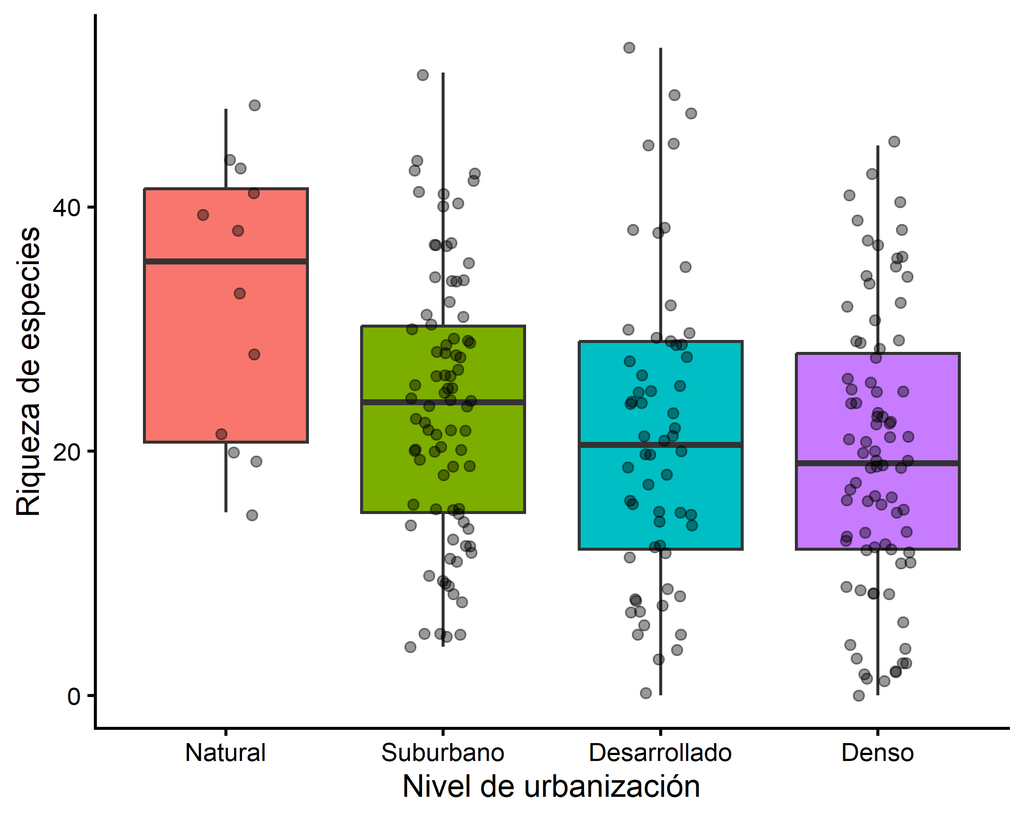

```r
ggplot(data = insectos, aes(x = Urban.Name, y = Richness, fill = Urban.Name)) +
  geom_boxplot(outlier.shape = NA) +
  geom_jitter(width = 0.15, alpha = 0.4) +
  theme_classic() +
  theme(legend.position = "none") +
  labs(x = "Nivel de urbanización", y = "Riqueza de especies")
```

```r
insectos %>%
  group_by(Urban.Name) %>%
  summarize(n = n(),
            media = mean(Richness),
            sd = sd(Richness))
```

```
## # A tibble: 4 × 4
##   Urban.Name       n media    sd
##   <fct>        <int> <dbl> <dbl>
## 1 Natural         12  32.4  11.4
## 2 Suburbano       84  23.6  10.9
## 3 Desarrollado    60  21.3  12.4
## 4 Denso           84  19.8  11.4
```

Las zonas **naturales** tienen la riqueza media más alta (32.4 especies por trampa), y la riqueza disminuye a medida que aumenta la urbanización (hasta 19.8 en las zonas densas). Las desviaciones típicas son muy parecidas en los cuatro grupos (entre 10.9 y 12.4), así que las varianzas parecen homogéneas.

### 4. Hipótesis

- $H_0$: $\mu_{Natural} = \mu_{Suburbano} = \mu_{Desarrollado} = \mu_{Denso}$. La riqueza media de especies es la misma en todos los niveles de urbanización.
- $H_A$: al menos una media es diferente. La riqueza media de especies difiere en al menos un nivel de urbanización.

### 5. Ajustar el modelo y comprobar los supuestos

```r
modelo_aov <- aov(Richness ~ Urban.Name, data = insectos)
```

**a) Normalidad de los residuos**

```r
shapiro.test(resid(modelo_aov))
```

```
##
##  Shapiro-Wilk normality test
##
## data:  resid(modelo_aov)
## W = 0.98187, p-value = 0.003671
```

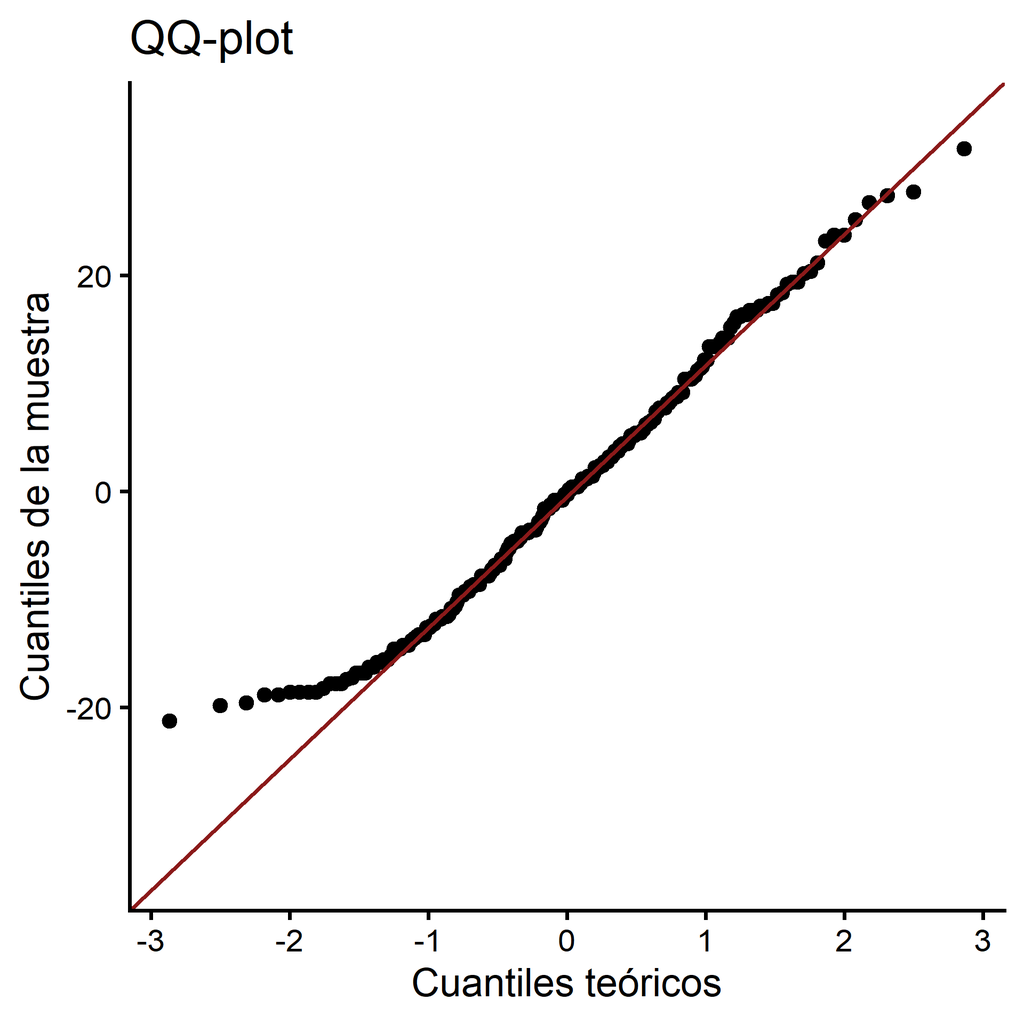

```r
QQ_plot(resid(modelo_aov))
```

**b) Homogeneidad de varianzas**

```r
leveneTest(Richness ~ Urban.Name, data = insectos)
```

```
## Levene's Test for Homogeneity of Variance (center = median)
##        Df F value Pr(>F)
## group   3  0.2771 0.8419
##       236
```

- **Shapiro-Wilk**: p = 0.004 < 0.05, rechazamos la normalidad de los residuos. Pero con 240 observaciones el test detecta desviaciones muy pequeñas: en el QQ-plot, los puntos siguen bien la recta en casi todo el rango, y solo se separan un poco en los extremos (la riqueza no puede ser negativa, y hay algunas trampas con 0 especies). Con una muestra tan grande, el ANOVA es robusto a esta desviación.
- **Levene**: p = 0.84 > 0.05, no rechazamos la homogeneidad de varianzas (coherente con las desviaciones típicas tan parecidas del paso 3).

Podemos hacer el ANOVA, y en el paso 9 lo comprobaremos con Kruskal-Wallis.

### 6. El test de ANOVA

```r
summary(modelo_aov)
```

```
##              Df Sum Sq Mean Sq F value  Pr(>F)
## Urban.Name    3   1944   647.9   4.898 0.00254 **
## Residuals   236  31216   132.3
## ---
## Signif. codes:  0 '***' 0.001 '**' 0.01 '*' 0.05 '.' 0.1 ' ' 1
```

*F* = 4.90, con 3 y 236 grados de libertad, p = 0.0025.

```r
qf(0.95, df1 = 3, df2 = 236)
```

```
## [1] 2.642851
```

*F* = 4.90 > *F* crítica = 2.64, y p = 0.0025 < 0.05: las dos formas llevan a la misma conclusión. **Rechazamos $H_0$**: la riqueza media de especies difiere en al menos un nivel de urbanización.

### 7. Tamaño del efecto: $R^2$

**a) A mano**, con las sumas de cuadrados de la tabla:

```r
SS_entre  <- 1944
SS_dentro <- 31216
SS_entre / (SS_entre + SS_dentro)
```

```
## [1] 0.05862485
```

**b) Con `R`:**

```r
summary(lm(Richness ~ Urban.Name, data = insectos))
```

```
##
## Call:
## lm(formula = Richness ~ Urban.Name, data = insectos)
##
## Residuals:
##     Min      1Q  Median      3Q     Max
## -21.267  -8.673  -0.267   7.733  31.733
##
## Coefficients:
##                        Estimate Std. Error t value Pr(>|t|)
## (Intercept)              32.417      3.320   9.764  < 2e-16 ***
## Urban.NameSuburbano      -8.798      3.549  -2.479 0.013886 *
## Urban.NameDesarrollado  -11.150      3.637  -3.066 0.002424 **
## Urban.NameDenso         -12.583      3.549  -3.545 0.000473 ***
## ---
## Signif. codes:  0 '***' 0.001 '**' 0.01 '*' 0.05 '.' 0.1 ' ' 1
##
## Residual standard error: 11.5 on 236 degrees of freedom
## Multiple R-squared:  0.05862,    Adjusted R-squared:  0.04665
## F-statistic: 4.898 on 3 and 236 DF,  p-value: 0.002541
```

**¿Por qué el p-valor es tan pequeño y el $R^2$ tan bajo?** Porque son dos cosas distintas:

- El **p-valor** depende del tamaño de la muestra: con 240 trampas, podemos detectar con mucha confianza diferencias aunque sean modestas.
- El **$R^2$** nos dice cuánto importa el factor: el 94% restante de la variabilidad se debe a otros factores que no están en el modelo (el tipo de vegetación junto a cada trampa, la temperatura, la época del año, la variación aleatoria entre trampas…).

La urbanización tiene un efecto **real** (significativo) sobre la biodiversidad de insectos, pero explica solo una parte pequeña de las diferencias entre trampas.

### 8. Test *post hoc*: Tukey

```r
TukeyHSD(modelo_aov)
```

```
##   Tukey multiple comparisons of means
##     95% family-wise confidence level
##
## Fit: aov(formula = Richness ~ Urban.Name, data = insectos)
##
## $Urban.Name
##                              diff        lwr        upr     p adj
## Suburbano-Natural       -8.797619 -17.981100  0.3858618 0.0658910
## Desarrollado-Natural   -11.150000 -20.560268 -1.7397324 0.0128693
## Denso-Natural          -12.583333 -21.766814 -3.3998525 0.0026479
## Desarrollado-Suburbano  -2.352381  -7.382381  2.6776186 0.6210733
## Denso-Suburbano         -3.785714  -8.377455  0.8060261 0.1456297
## Denso-Desarrollado      -1.433333  -6.463333  3.5966663 0.8819569
```

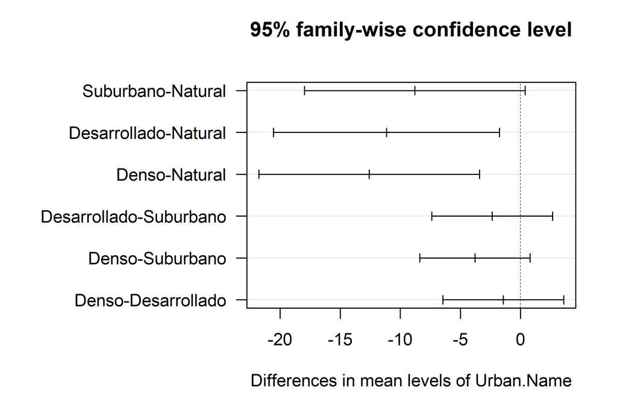

```r
par(mar = c(5, 12, 4, 2))  # margen izquierdo más ancho para que quepan los nombres
plot(TukeyHSD(modelo_aov), las = 1)
```

Dos parejas difieren significativamente (su intervalo de confianza no incluye el 0):

- **Desarrollado − Natural**: 11.2 especies menos en las zonas desarrolladas (p = 0.013).
- **Denso − Natural**: 12.6 especies menos en las zonas densas (p = 0.003).

La diferencia Suburbano − Natural (8.8 especies menos) no llega a ser significativa (p = 0.066), y entre los tres niveles urbanos no hay diferencias significativas.

### 9. Comprobación no paramétrica: Kruskal-Wallis y Dunn

```r
kruskal.test(Richness ~ Urban.Name, data = insectos)
```

```
##
##  Kruskal-Wallis rank sum test
##
## data:  Richness by Urban.Name
## Kruskal-Wallis chi-squared = 12.498, df = 3, p-value = 0.005858
```

```r
dunn_test(insectos, Richness ~ Urban.Name, p.adjust.method = "holm")
```

```
## # A tibble: 6 × 9
##   .y.      group1      group2    n1    n2 statistic       p   p.adj p.adj.signif
## * <chr>    <chr>       <chr>  <int> <int>     <dbl>   <dbl>   <dbl> <chr>
## 1 Richness Natural     Subur…    12    84    -2.11  0.0350  0.140   ns
## 2 Richness Natural     Desar…    12    60    -2.79  0.00523 0.0262  *
## 3 Richness Natural     Denso     12    84    -3.16  0.00159 0.00954 **
## 4 Richness Suburbano   Desar…    84    60    -1.37  0.169   0.339   ns
## 5 Richness Suburbano   Denso     84    84    -2.10  0.0359  0.140   ns
## 6 Richness Desarrolla… Denso     60    84    -0.541 0.588   0.588   ns
```

```r
kruskal_effsize(insectos, Richness ~ Urban.Name)
```

```
## # A tibble: 1 × 5
##   .y.          n effsize method  magnitude
## * <chr>    <int>   <dbl> <chr>   <ord>
## 1 Richness   240  0.0402 eta2[H] small
```

# Parte 2. Regresión lineal simple: endogamia en lobos

### 1. Leer los datos

```r
lobos <- read.csv("chap16e2InbreedingWolves.csv")
head(lobos)
```

```
##   inbreedCoef nPups
## 1        0.00     6
## 2        0.00     6
## 3        0.13     7
## 4        0.13     5
## 5        0.13     4
## 6        0.19     8
```

```r
nrow(lobos)
```

```
## [1] 24
```

La variable explicativa ($X$) es el coeficiente de endogamia (`inbreedCoef`), y la variable respuesta ($Y$), el número de crías que sobreviven (`nPups`).

### 2. Visualizar los datos

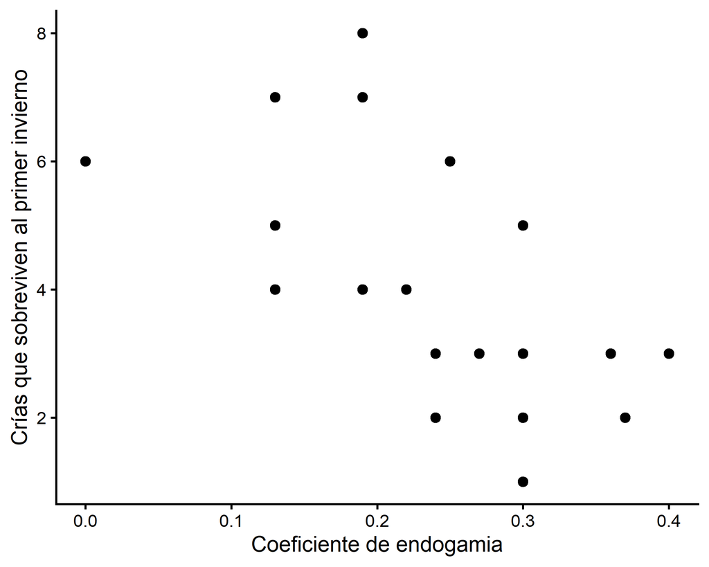

```r
ggplot(data = lobos, aes(x = inbreedCoef, y = nPups)) +
  geom_point(size = 2) +
  theme_classic() +
  labs(x = "Coeficiente de endogamia", y = "Crías que sobreviven al primer invierno")
```

La relación es **negativa**: las camadas más endogámicas tienden a tener menos crías. Parece aproximadamente lineal, aunque con bastante dispersión.

### 3. Correlación

```r
cor.test(~ nPups + inbreedCoef, data = lobos)
```

```
##
##  Pearson's product-moment correlation
##
## data:  nPups and inbreedCoef
## t = -3.5893, df = 22, p-value = 0.001633
## alternative hypothesis: true correlation is not equal to 0
## 95 percent confidence interval:
##  -0.8120418 -0.2706791
## sample estimates:
##        cor
## -0.6077184
```

$r$ = −0.61, p = 0.0016: hay una correlación negativa, moderadamente fuerte y significativa.

### 4. Ajustar la recta de regresión

```r
modelo_lm <- lm(nPups ~ inbreedCoef, data = lobos)
summary(modelo_lm)
```

```
##
## Call:
## lm(formula = nPups ~ inbreedCoef, data = lobos)
##
## Residuals:
##     Min      1Q  Median      3Q     Max
## -2.1332 -0.8200 -0.4345  0.6680  3.6076
##
## Coefficients:
##             Estimate Std. Error t value Pr(>|t|)
## (Intercept)   6.5672     0.7906   8.307 3.14e-08 ***
## inbreedCoef -11.4467     3.1891  -3.589  0.00163 **
## ---
## Signif. codes:  0 '***' 0.001 '**' 0.01 '*' 0.05 '.' 0.1 ' ' 1
##
## Residual standard error: 1.523 on 22 degrees of freedom
## Multiple R-squared:  0.3693, Adjusted R-squared:  0.3407
## F-statistic: 12.88 on 1 and 22 DF,  p-value: 0.001633
```

**a)** Ecuación de la recta: $\text{nPups} = 6.57 - 11.45 \times \text{inbreedCoef}$

**b)** La pendiente es −11.45: por cada aumento de 1 en el coeficiente de endogamia, sobreviven de media 11.45 crías menos. Como el coeficiente va de 0 a 1, es más útil decirlo así: por cada aumento de **0.1** en el coeficiente de endogamia, sobreviven de media **1.14 crías menos** (−11.45 × 0.1). La ordenada en el origen (6.57) es el número medio de crías esperado en una camada sin endogamia.

**c)** Sí: p = 0.0016 < 0.05, rechazamos $H_0$: $\beta = 0$. El p-valor es **exactamente el mismo** que el de la correlación: en la regresión lineal simple, el contraste de la pendiente y el de la correlación son equivalentes (incluso el estadístico *t* = −3.59 coincide).

### 5. Comprobar los supuestos

**b) Normalidad de los residuos**

```r
shapiro.test(resid(modelo_lm))
```

```
##
##  Shapiro-Wilk normality test
##
## data:  resid(modelo_lm)
## W = 0.9067, p-value = 0.02992
```

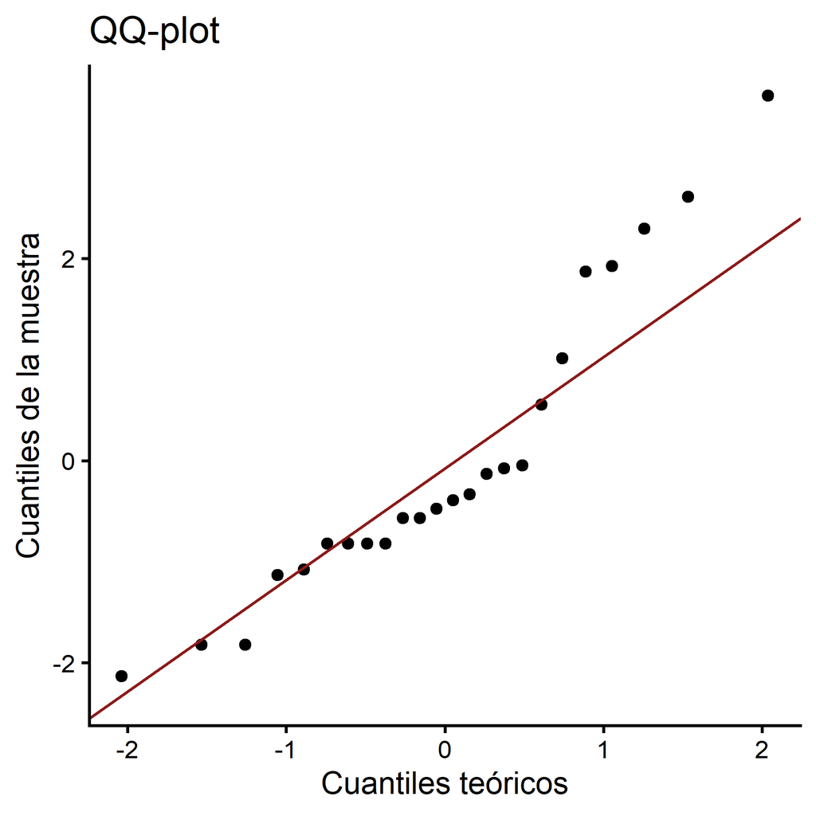

```r
QQ_plot(resid(modelo_lm))
```

**c) Homocedasticidad**

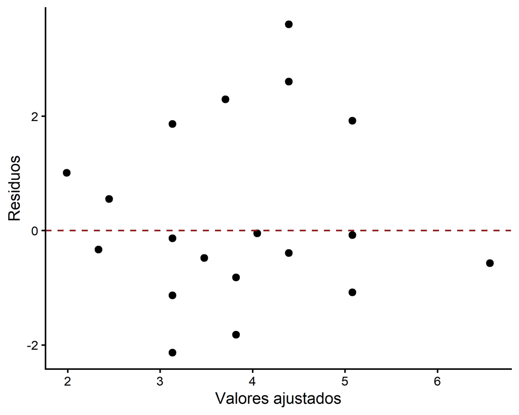

```r
residuos_lobos <- data.frame(ajustados = fitted(modelo_lm),
                             residuos  = resid(modelo_lm))

ggplot(residuos_lobos, aes(x = ajustados, y = residuos)) +
  geom_point(size = 2) +
  geom_hline(yintercept = 0, linetype = "dashed", color = "firebrick4") +
  theme_classic() +
  labs(x = "Valores ajustados", y = "Residuos")
```

- **Linealidad**: razonable en el diagrama de dispersión.
- **Normalidad**: Shapiro-Wilk da p = 0.03, y en el QQ-plot los residuos forman “escalones” y se separan de la recta en el extremo superior. Es lo esperable: `nPups` es un recuento con pocos valores posibles (de 1 a 8), así que los residuos no pueden ser continuos. Hay además un residuo grande (una camada con muchas más crías de las esperadas).
- **Homocedasticidad**: los residuos se reparten alrededor del 0 sin una forma de embudo clara.

La desviación de la normalidad es moderada. Como comprobación, podemos usar la **correlación de Spearman**, que no asume normalidad:

```r
cor.test(~ nPups + inbreedCoef, data = lobos, method = "spearman", exact = FALSE)
```

```
##
##  Spearman's rank correlation rho
##
## data:  nPups and inbreedCoef
## S = 3809.4, p-value = 0.0004966
## alternative hypothesis: true rho is not equal to 0
## sample estimates:
##        rho
## -0.6562775
```

La correlación de Spearman también es negativa y significativa ($\rho$ = −0.66, p = 0.0005), así que la conclusión no depende del supuesto de normalidad.

### 6. Tamaño del efecto: $R^2$

**a)** $R^2$ = 0.37: el coeficiente de endogamia explica el **37%** de la variabilidad del número de crías que sobreviven.

**b)**

```r
cor(lobos$nPups, lobos$inbreedCoef)^2
```

```
## [1] 0.3693217
```

$r^2 = (-0.61)^2 = 0.37 = R^2$.

**c)**

```r
anova(modelo_lm)
```

```
## Analysis of Variance Table
##
## Response: nPups
##             Df Sum Sq Mean Sq F value   Pr(>F)
## inbreedCoef  1 29.900 29.8997  12.883 0.001633 **
## Residuals   22 51.059  2.3208
## ---
## Signif. codes:  0 '***' 0.001 '**' 0.01 '*' 0.05 '.' 0.1 ' ' 1
```

```r
29.900 / (29.900 + 51.059)
```

```
## [1] 0.3693227
```

Con la tabla ANOVA de la regresión también obtenemos $R^2$ = 0.37. Además, la *F* de esta tabla (12.88) es el cuadrado de la *t* de la pendiente: $(-3.59)^2 = 12.88$.

El modelo de los lobos explica mucha más variabilidad (37%) que el de la urbanización (5.9%), aunque en los dos casos el efecto sea significativo.

### 7. Visualizar la recta y hacer predicciones

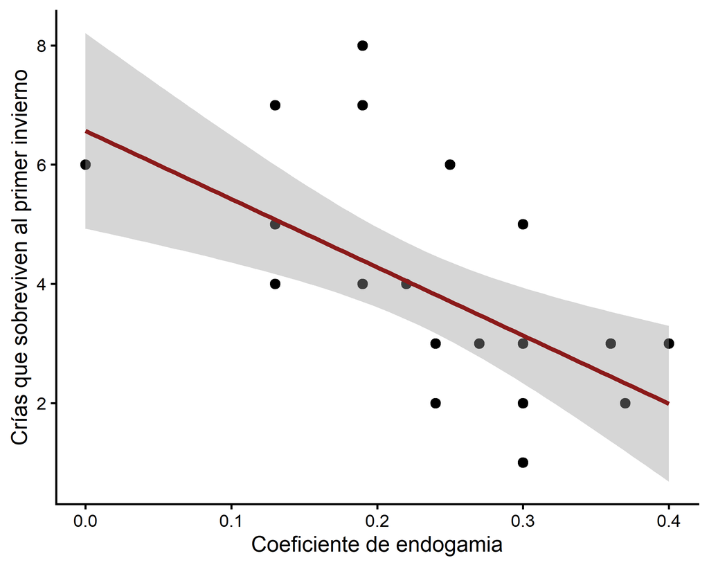

```r
ggplot(data = lobos, aes(x = inbreedCoef, y = nPups)) +
  geom_point(size = 2) +
  geom_smooth(method = "lm", color = "firebrick4") +
  theme_classic() +
  labs(x = "Coeficiente de endogamia", y = "Crías que sobreviven al primer invierno")
```

```r
predict(modelo_lm, newdata = data.frame(inbreedCoef = 0.25))
```

```
##        1
## 3.705553
```

```r
6.567 - 11.447 * 0.25
```

```
## [1] 3.70525
```

```r
range(lobos$inbreedCoef)
```

```
## [1] 0.0 0.4
```

Esperaríamos **3.7 crías** en una camada con un coeficiente de endogamia de 0.25, el mismo valor que da la ecuación de la recta.

**No** tendría sentido predecir con un coeficiente de 0.8: los datos solo van de 0 a 0.4, y no sabemos si la relación sigue siendo lineal fuera de ese rango (**extrapolación**). De hecho, la recta predeciría un número de crías negativo ($6.57 - 11.45 \times 0.8 = -2.6$), que es imposible.

### 8. Conclusión

El número de crías que sobreviven a su primer invierno **disminuye** con el coeficiente de endogamia ($b$ = −11.45, p = 0.0016). Por cada aumento de 0.1 en el coeficiente de endogamia, sobreviven de media **1.14** crías menos. La endogamia explica el **37%** de la variabilidad en el número de crías ($R^2$ = 0.37).

# Para practicar: variables ambientales y biodiversidad

```r
summary(lm(Richness ~ Temp.Mean, data = insectos))
```

```
##
## Call:
## lm(formula = Richness ~ Temp.Mean, data = insectos)
##
## Residuals:
##      Min       1Q   Median       3Q      Max
## -23.6245  -8.8367  -0.2301   7.3047  30.6316
##
## Coefficients:
##             Estimate Std. Error t value Pr(>|t|)
## (Intercept)  16.8636     3.9941   4.222 3.45e-05 ***
## Temp.Mean     0.2710     0.2011   1.347    0.179
## ---
## Signif. codes:  0 '***' 0.001 '**' 0.01 '*' 0.05 '.' 0.1 ' ' 1
##
## Residual standard error: 11.76 on 238 degrees of freedom
## Multiple R-squared:  0.007566,   Adjusted R-squared:  0.003397
## F-statistic: 1.815 on 1 and 238 DF,  p-value: 0.1792
```

```r
summary(lm(Richness ~ Rh.Mean, data = insectos))
```

```
##
## Call:
## lm(formula = Richness ~ Rh.Mean, data = insectos)
##
## Residuals:
##      Min       1Q   Median       3Q      Max
## -23.1409  -8.7394  -0.2243   7.4750  29.4987
##
## Coefficients:
##             Estimate Std. Error t value Pr(>|t|)
## (Intercept) 29.76398    3.99734   7.446 1.76e-12 ***
## Rh.Mean     -0.11872    0.06117  -1.941   0.0535 .
## ---
## Signif. codes:  0 '***' 0.001 '**' 0.01 '*' 0.05 '.' 0.1 ' ' 1
##
## Residual standard error: 11.71 on 238 degrees of freedom
## Multiple R-squared:  0.01558,    Adjusted R-squared:  0.01144
## F-statistic: 3.767 on 1 and 238 DF,  p-value: 0.05346
```

```r
summary(lm(Richness ~ Photoperiod, data = insectos))
```

```
##
## Call:
## lm(formula = Richness ~ Photoperiod, data = insectos)
##
## Residuals:
##      Min       1Q   Median       3Q      Max
## -26.0812  -7.0613   0.4458   7.7840  26.0465
##
## Coefficients:
##             Estimate Std. Error t value Pr(>|t|)
## (Intercept) -10.4059     5.5678  -1.869   0.0629 .
## Photoperiod   2.6717     0.4532   5.895 1.28e-08 ***
## ---
## Signif. codes:  0 '***' 0.001 '**' 0.01 '*' 0.05 '.' 0.1 ' ' 1
##
## Residual standard error: 11.03 on 238 degrees of freedom
## Multiple R-squared:  0.1274, Adjusted R-squared:  0.1237
## F-statistic: 34.75 on 1 and 238 DF,  p-value: 1.277e-08
```

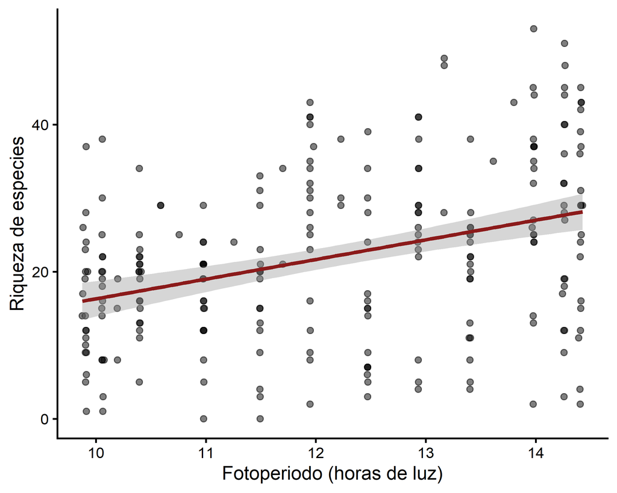

| Variable | Pendiente | p-valor | $R^2$ |
| --- | --- | --- | --- |
| `Temp.Mean` | 0.27 | 0.18 | 0.008 |
| `Rh.Mean` | −0.12 | 0.053 | 0.016 |
| `Photoperiod` | 2.67 | 1.3 × 10⁻⁸ | 0.127 |

```r
ggplot(data = insectos, aes(x = Photoperiod, y = Richness)) +
  geom_point(alpha = 0.5) +
  geom_smooth(method = "lm", color = "firebrick4") +
  theme_classic() +
  labs(x = "Fotoperiodo (horas de luz)", y = "Riqueza de especies")
```

- La temperatura y la humedad no tienen una relación significativa con la riqueza de especies (p > 0.05), y su $R^2$ es prácticamente 0.
- El **fotoperiodo** sí: por cada hora más de luz, se capturan de media 2.7 especies más, y explica el **12.7%** de la variabilidad (más que el nivel de urbanización).
- **Cuidado con la interpretación:** el fotoperiodo depende de la **fecha** en que se puso la trampa. Probablemente no es la luz en sí lo que aumenta la riqueza, sino la **época del año**: en los meses con más horas de luz hay más insectos activos. Es un ejemplo de que una relación significativa no implica causalidad.